# Numeric Mapping

Primer embarazo / First Pregnancy: 0 = No 1 = Yes

Nivel Estudios / level of education 1 = primary 2 = secondary 3 = university students 4 = without studies

Aspecto Pelo/ Hair Appearance 0 = dyed 1 = natural

Deporte / Sport 0 = No 1 = Yes

Profesión / Profession 1 = unemployment 2 = Head of nurse 3 = Doctor 4 = Nurse 5 = housewife 6 = teacher 7 = management 8 = dental clinic 9 = banking 10 = untrained 11 = psychologist 12 = engineer

depreposparto / depress post partum 1 = sindepre? 2 = condepre?

## Items

### age

#### Distribution

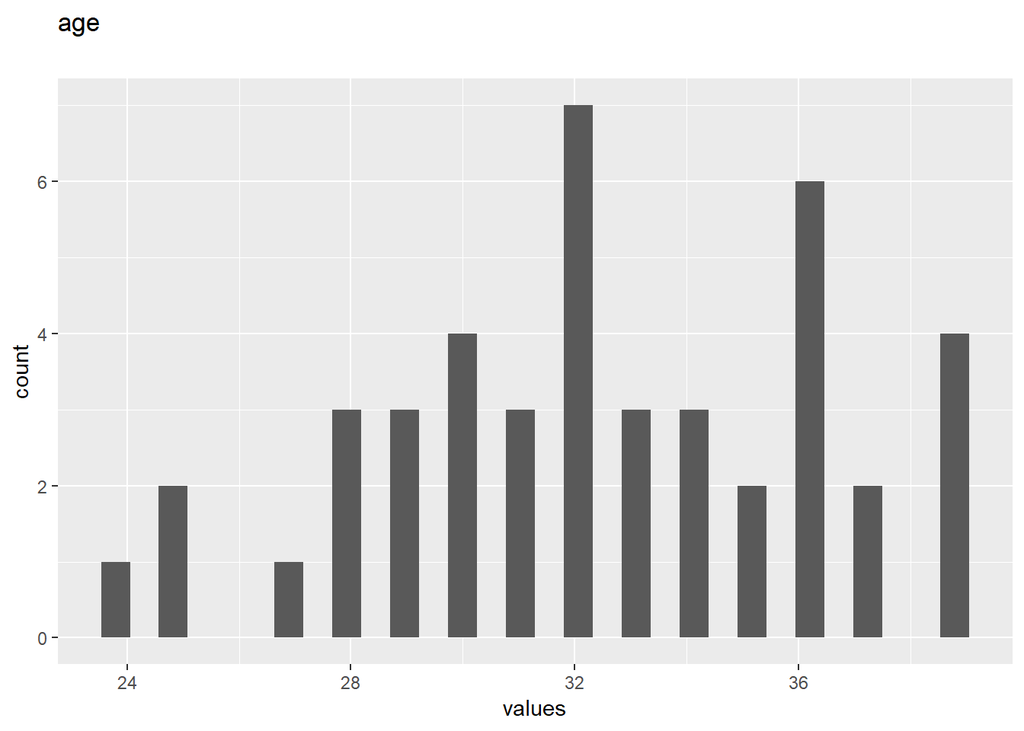

0 missings.

#### Summary statistics

[output not shown]

### education_level

#### Distribution

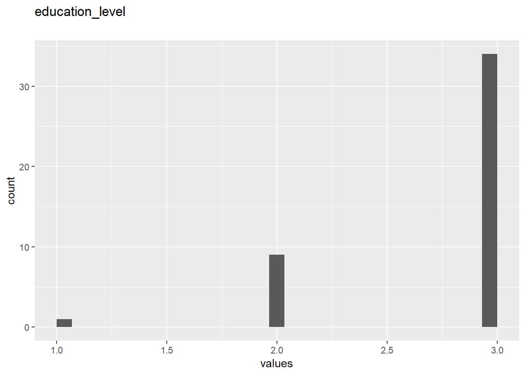

0 missings.

#### Summary statistics

[output not shown]

### nationality

#### Distribution

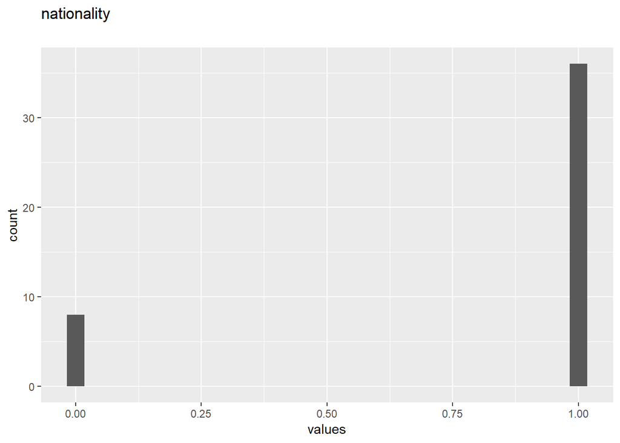

0 missings.

#### Summary statistics

[output not shown]

### postpartum_depression

#### Distribution

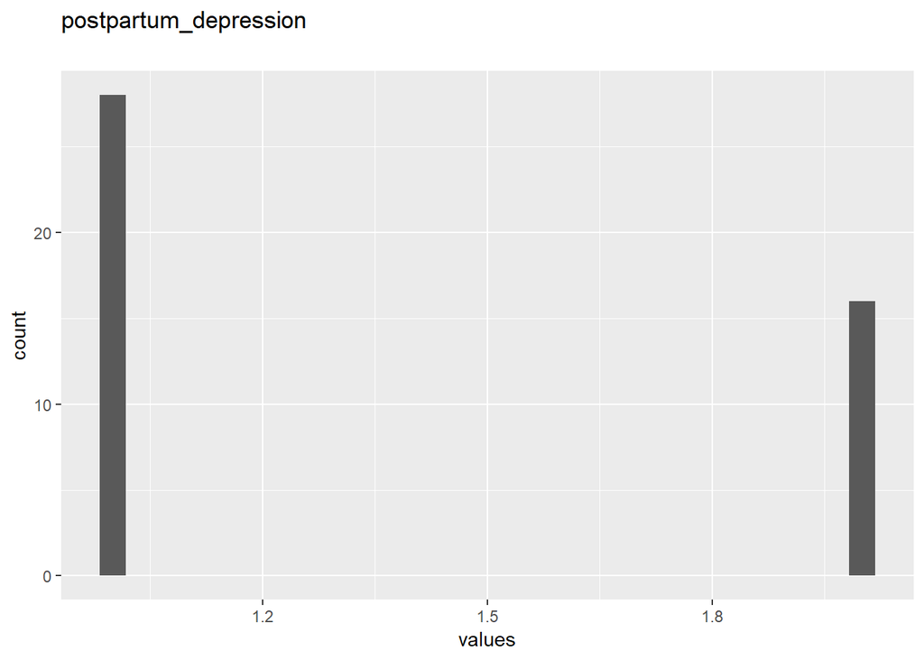

0 missings.

#### Summary statistics

[output not shown]

### employed

#### Distribution

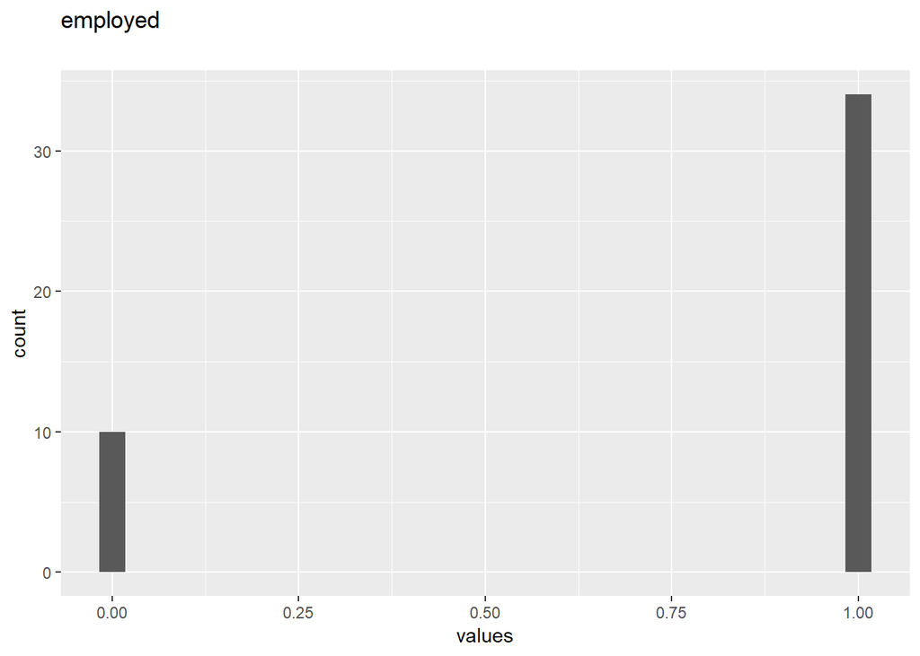

0 missings.

#### Summary statistics

[output not shown]

### occupation

#### Distribution

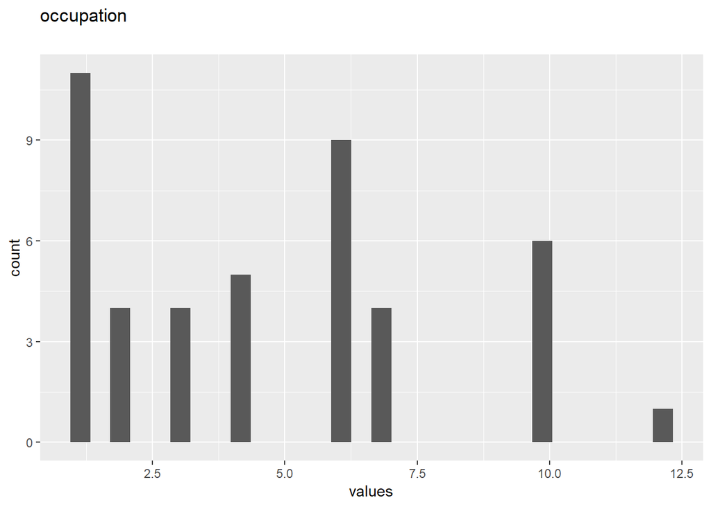

0 missings.

#### Summary statistics

[output not shown]

### sport

#### Distribution

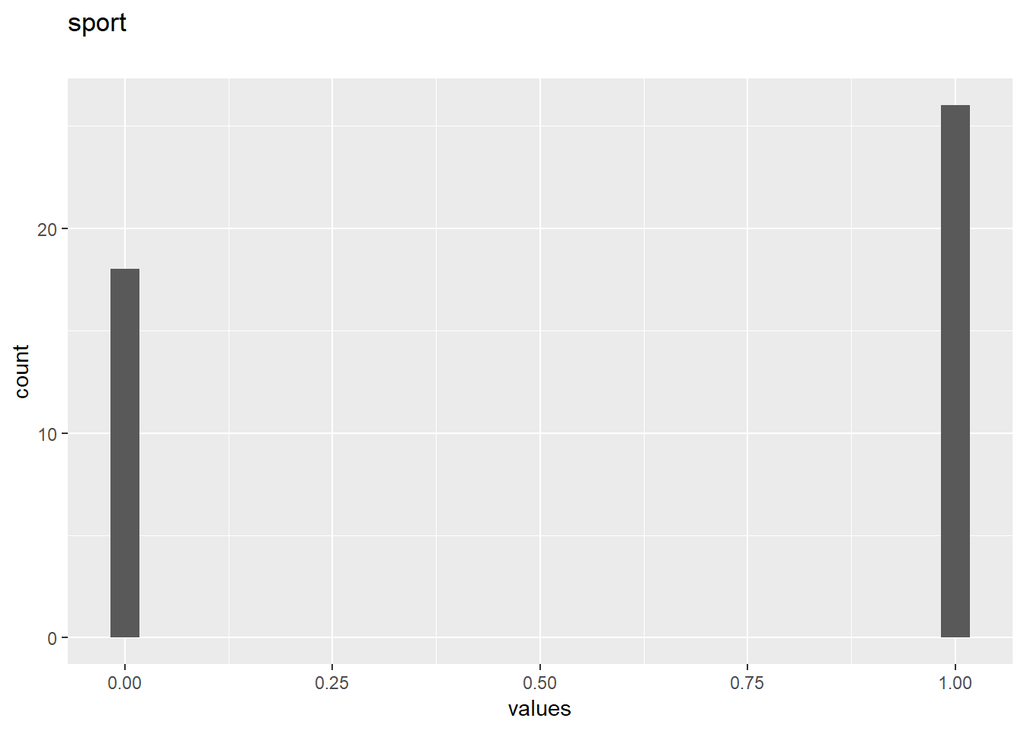

0 missings.

#### Summary statistics

[output not shown]

### pet

#### Distribution

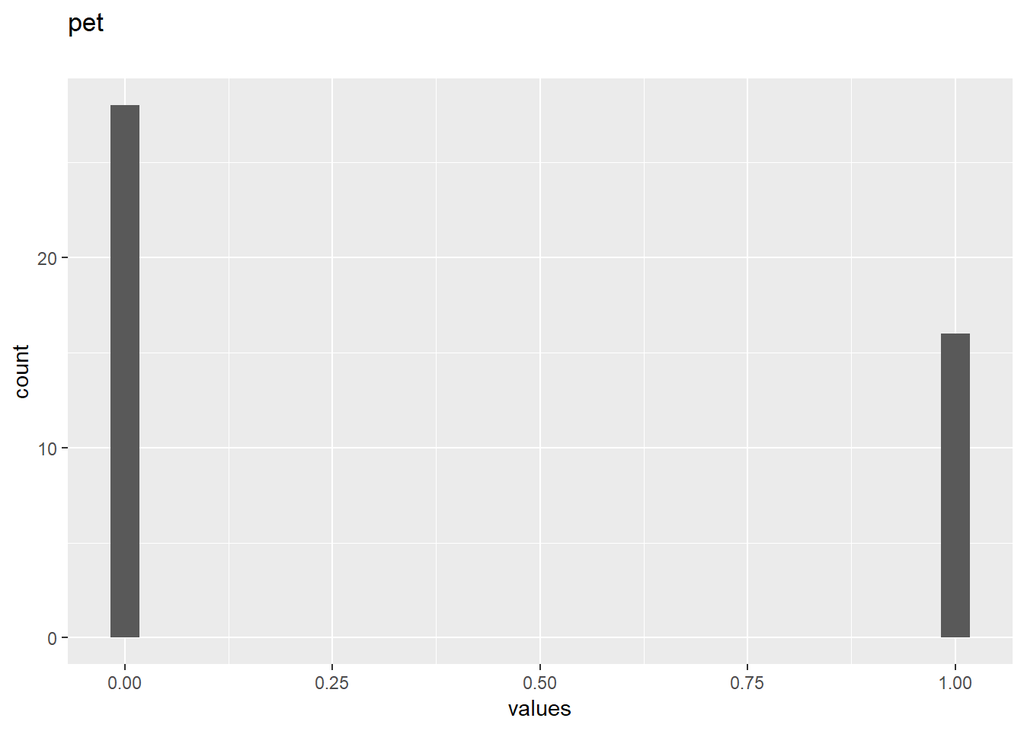

0 missings.

#### Summary statistics

[output not shown]

### dyed_hair

#### Distribution

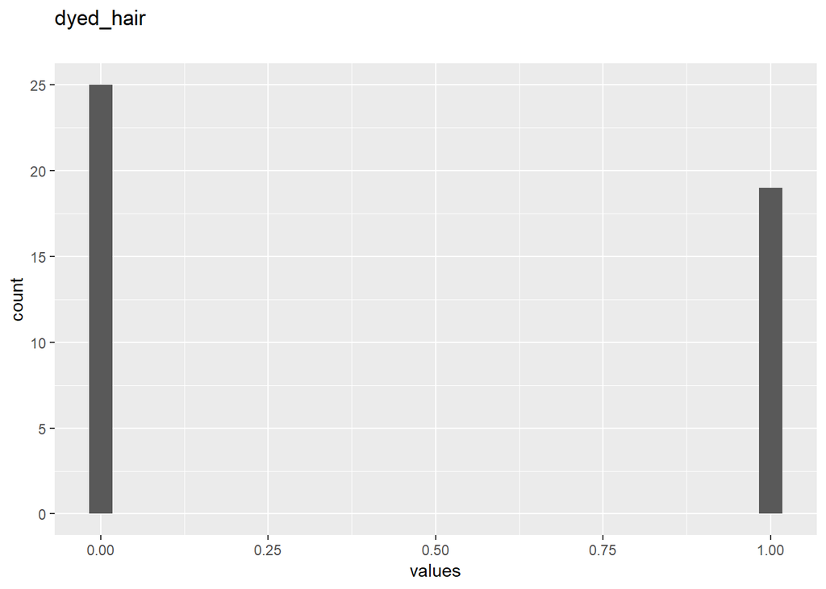

0 missings.

#### Summary statistics

[output not shown]

### first_pregnancy

#### Distribution

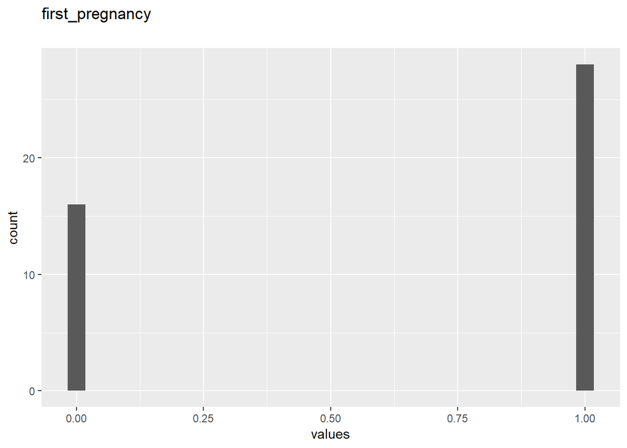

0 missings.

#### Summary statistics

[output not shown]

### wanted_pregnancy

#### Distribution

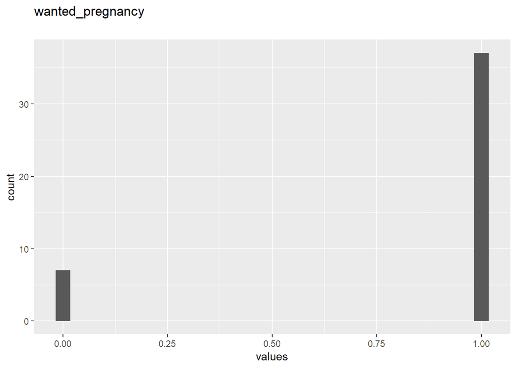

0 missings.

#### Summary statistics

[output not shown]

### pregnancy_method

#### Distribution

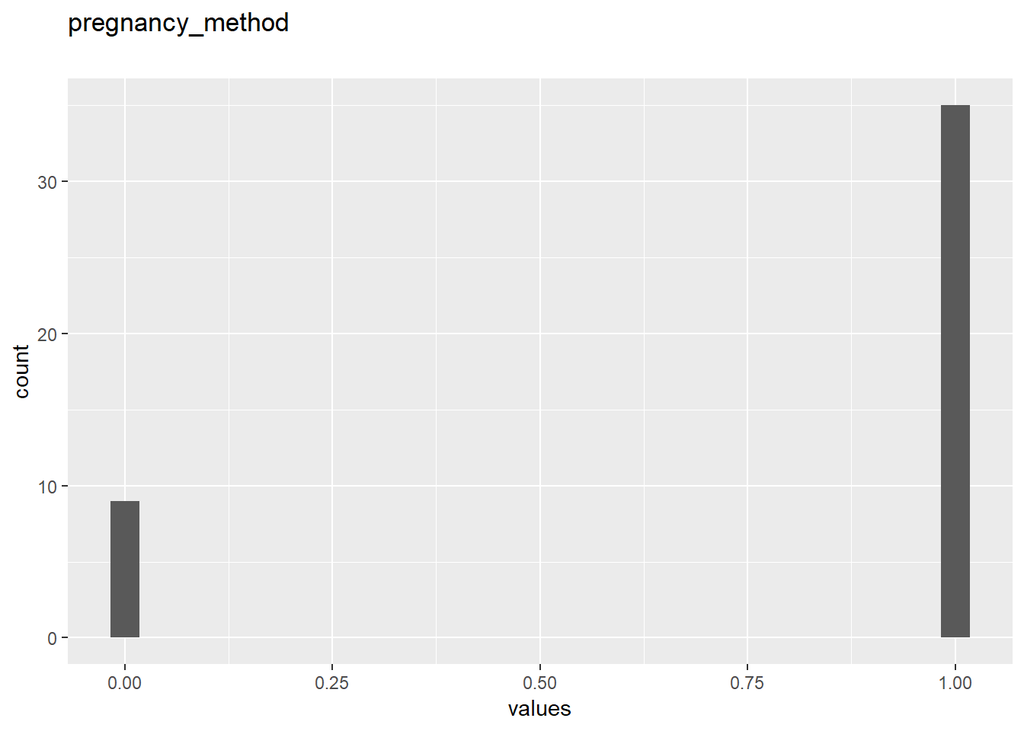

0 missings.

#### Summary statistics

[output not shown]

### previous_miscarriage

#### Distribution

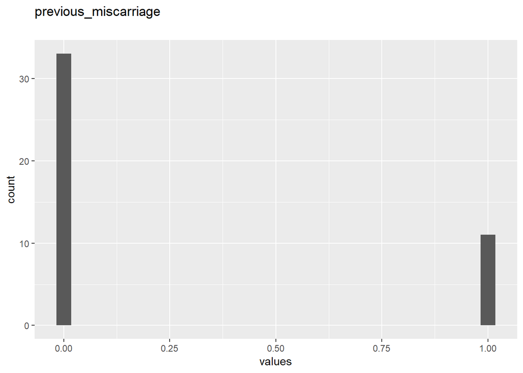

0 missings.

#### Summary statistics

[output not shown]

### fetus_sex

#### Distribution

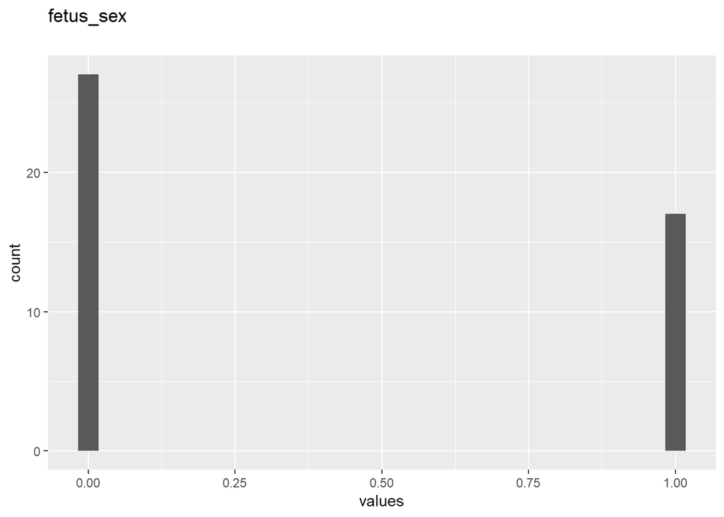

0 missings.

#### Summary statistics

[output not shown]

### epds

#### Distribution

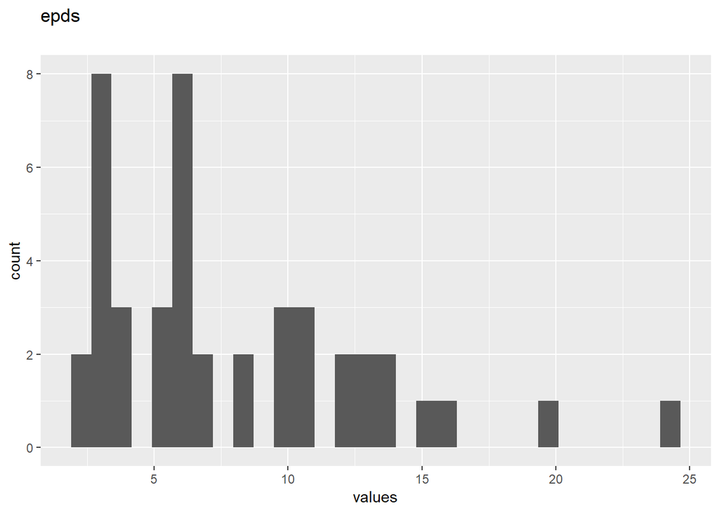

0 missings.

#### Summary statistics

[output not shown]

### depression_tri1

#### Distribution

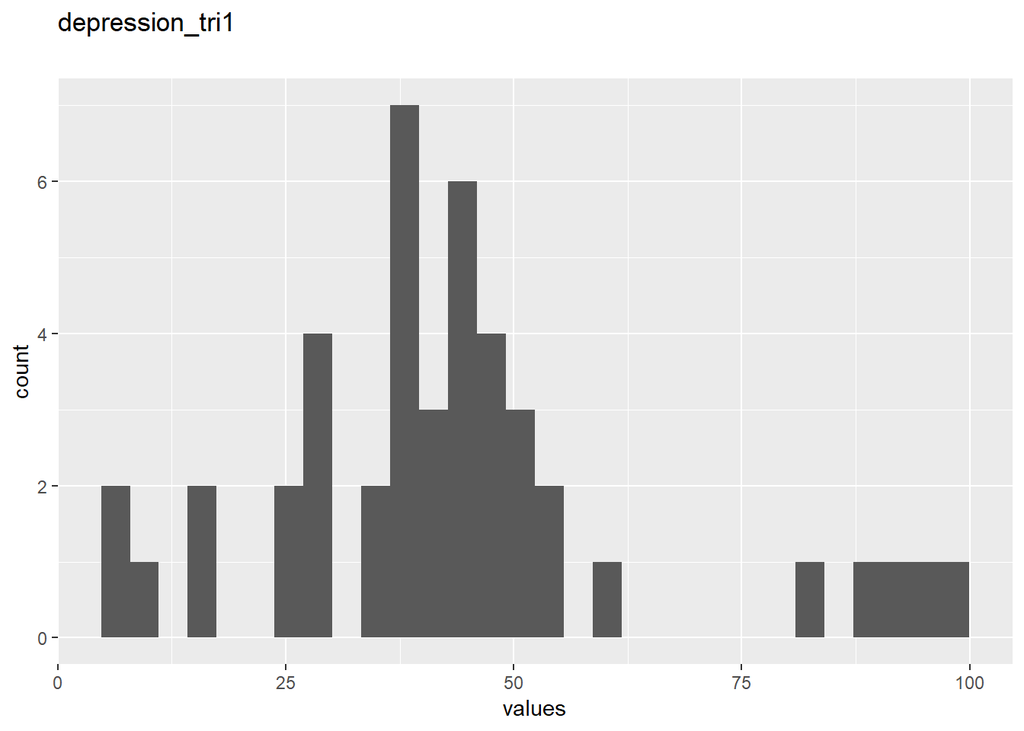

0 missings.

#### Summary statistics

[output not shown]

### depression_tri2

#### Distribution

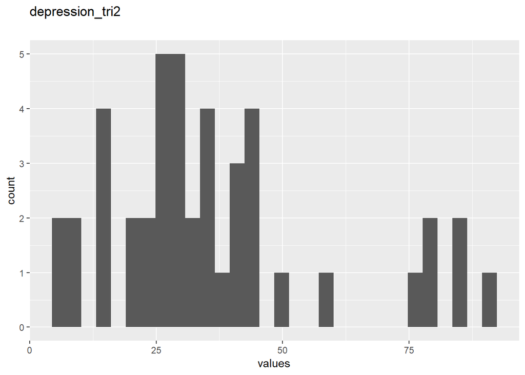

0 missings.

#### Summary statistics

[output not shown]

### depression_tri3

#### Distribution

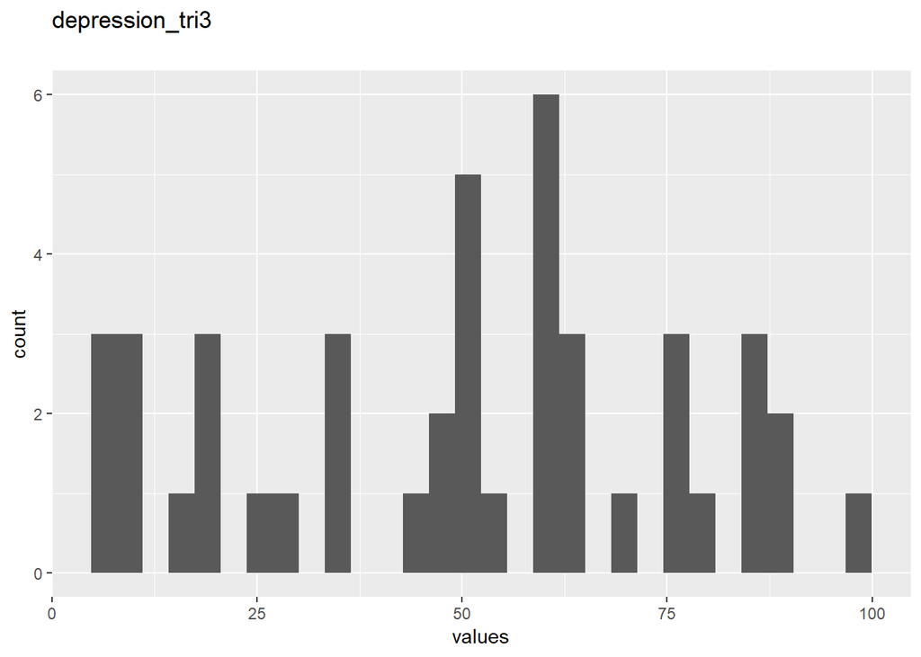

0 missings.

#### Summary statistics

[output not shown]

### cortisol_tri1

#### Distribution

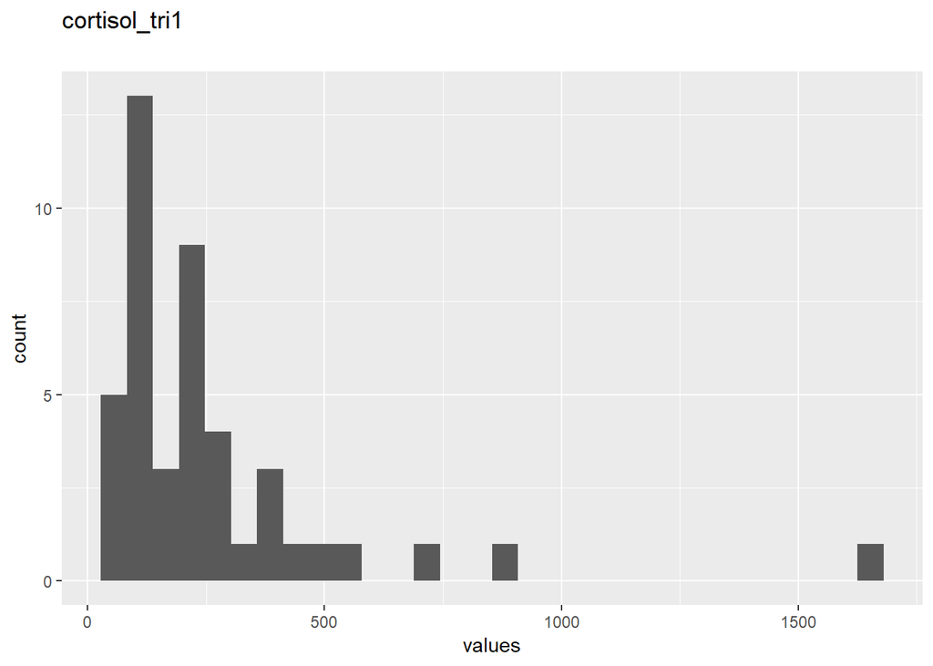

0 missings.

#### Summary statistics

[output not shown]

### cortisol_tri2

#### Distribution

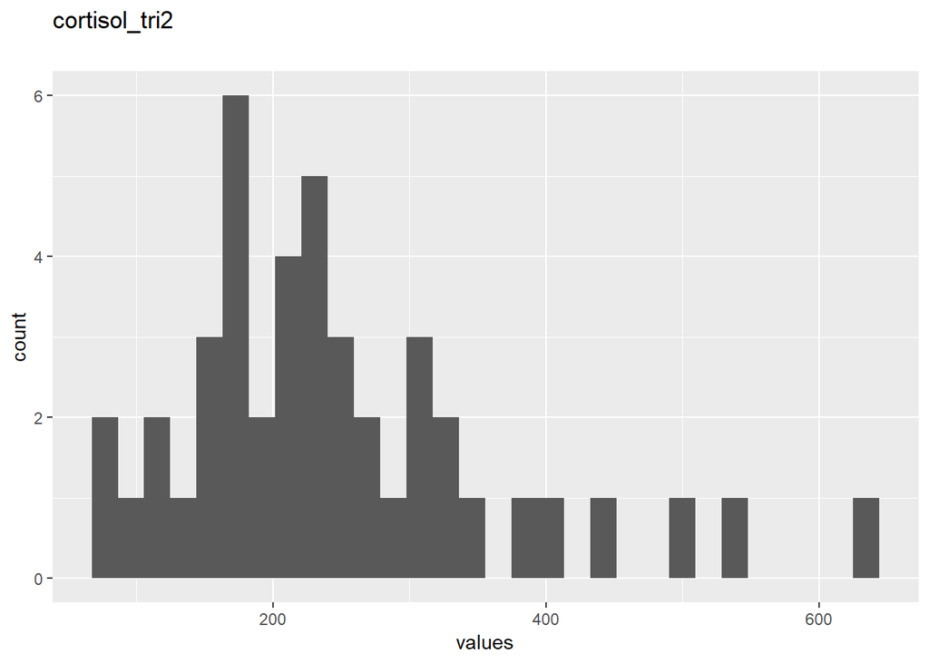

0 missings.

#### Summary statistics

[output not shown]

### cortisol_tri3

#### Distribution

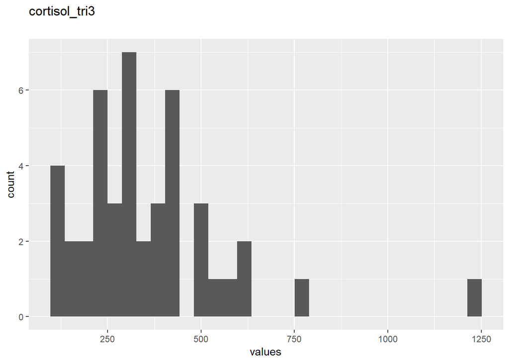

0 missings.

#### Summary statistics

[output not shown]

## Missingness report

Among those who finished the survey. Only variables that have missings are shown.

## Codebook table

[output not shown]

[output cut: 11 more lines]